# PCA and T-SNE IP

Mary njuguna

2022-06-09

# Research Question

You are a Data analyst at Carrefour Kenya and are currently undertaking a project that will inform the marketing department on the most relevant marketing strategies that will result in the highest no. of sales (total price including tax). Your project has been divided into four parts where you’ll explore a recent marketing dataset by performing various unsupervised learning techniques and later providing recommendations based on your insights.

Part 1: Dimensionality Reduction

This section of the project entails reducing your dataset to a low dimensional dataset using the t-SNE algorithm or PCA. You will be required to perform your analysis and provide insights gained from your analysis.

Part 2: Feature Selection

This section requires you to perform feature selection through the use of the unsupervised learning methods learned earlier this week. You will be required to perform your analysis and provide insights on the features that contribute the most information to the dataset.

# Loading The Libraries

```r
library(ggplot2)
library(tidyverse)
library(dplyr)
library(ggpubr)
library(anomalize)
library(rstatix)
library(psych)
library(tidyr)
library(lubridate)
library(stringr)
library(reshape2)
library(caret)
```

# loading the data

```r
pca_df<- read.csv("http://bit.ly/CarreFourDataset")
```

## Previewing the data

```r
#Viewing the head of the data
head(pca_df)
```

```
##    Invoice.ID Branch Customer.type Gender           Product.line Unit.price
## 1 750-67-8428      A        Member Female      Health and beauty      74.69
## 2 226-31-3081      C        Normal Female Electronic accessories      15.28
## 3 631-41-3108      A        Normal   Male     Home and lifestyle      46.33
## 4 123-19-1176      A        Member   Male      Health and beauty      58.22
## 5 373-73-7910      A        Normal   Male      Sports and travel      86.31
## 6 699-14-3026      C        Normal   Male Electronic accessories      85.39
##   Quantity     Tax      Date  Time     Payment   cogs gross.margin.percentage
## 1        7 26.1415  1/5/2019 13:08     Ewallet 522.83                4.761905
## 2        5  3.8200  3/8/2019 10:29        Cash  76.40                4.761905
## 3        7 16.2155  3/3/2019 13:23 Credit card 324.31                4.761905
## 4        8 23.2880 1/27/2019 20:33     Ewallet 465.76                4.761905
## 5        7 30.2085  2/8/2019 10:37     Ewallet 604.17                4.761905
## 6        7 29.8865 3/25/2019 18:30     Ewallet 597.73                4.761905
##   gross.income Rating    Total
## 1      26.1415    9.1 548.9715
## 2       3.8200    9.6  80.2200
## 3      16.2155    7.4 340.5255
## 4      23.2880    8.4 489.0480
## 5      30.2085    5.3 634.3785
## 6      29.8865    4.1 627.6165
```

```r
#Viewing the bottom part of the dataset
tail(pca_df)
```

```
##       Invoice.ID Branch Customer.type Gender           Product.line Unit.price
## 995  652-49-6720      C        Member Female Electronic accessories      60.95
## 996  233-67-5758      C        Normal   Male      Health and beauty      40.35
## 997  303-96-2227      B        Normal Female     Home and lifestyle      97.38
## 998  727-02-1313      A        Member   Male     Food and beverages      31.84
## 999  347-56-2442      A        Normal   Male     Home and lifestyle      65.82
## 1000 849-09-3807      A        Member Female    Fashion accessories      88.34
##      Quantity     Tax      Date  Time Payment   cogs gross.margin.percentage
## 995         1  3.0475 2/18/2019 11:40 Ewallet  60.95                4.761905
## 996         1  2.0175 1/29/2019 13:46 Ewallet  40.35                4.761905
## 997        10 48.6900  3/2/2019 17:16 Ewallet 973.80                4.761905
## 998         1  1.5920  2/9/2019 13:22    Cash  31.84                4.761905
## 999         1  3.2910 2/22/2019 15:33    Cash  65.82                4.761905
## 1000        7 30.9190 2/18/2019 13:28    Cash 618.38                4.761905
##      gross.income Rating     Total
## 995        3.0475    5.9   63.9975
## 996        2.0175    6.2   42.3675
## 997       48.6900    4.4 1022.4900
## 998        1.5920    7.7   33.4320
## 999        3.2910    4.1   69.1110
## 1000      30.9190    6.6  649.2990
```

```r
#printing the columns and rows
dim(pca_df)
```

```
## [1] 1000   16
```

The dataset has 16 columns and 1000 rows

```r
#Checking if the columns are correctly named
colnames(pca_df)
```

```
##  [1] "Invoice.ID"              "Branch"
##  [3] "Customer.type"           "Gender"
##  [5] "Product.line"            "Unit.price"
##  [7] "Quantity"                "Tax"
##  [9] "Date"                    "Time"
## [11] "Payment"                 "cogs"
## [13] "gross.margin.percentage" "gross.income"
## [15] "Rating"                  "Total"
```

```r
#Abstract(pca_df)
```

```r
#dataset type
class(pca_df)
```

```
## [1] "data.frame"
```

The dataset type is a dataframe

```r
# printing the structure of the dataset
glimpse(pca_df)
```

```
## Rows: 1,000
## Columns: 16
## $ Invoice.ID              <chr> "750-67-8428", "226-31-3081", "631-41-3108", "…
## $ Branch                  <chr> "A", "C", "A", "A", "A", "C", "A", "C", "A", "…
## $ Customer.type           <chr> "Member", "Normal", "Normal", "Member", "Norma…
## $ Gender                  <chr> "Female", "Female", "Male", "Male", "Male", "M…
## $ Product.line            <chr> "Health and beauty", "Electronic accessories",…
## $ Unit.price              <dbl> 74.69, 15.28, 46.33, 58.22, 86.31, 85.39, 68.8…
## $ Quantity                <int> 7, 5, 7, 8, 7, 7, 6, 10, 2, 3, 4, 4, 5, 10, 10…
## $ Tax                     <dbl> 26.1415, 3.8200, 16.2155, 23.2880, 30.2085, 29…
## $ Date                    <chr> "1/5/2019", "3/8/2019", "3/3/2019", "1/27/2019…
## $ Time                    <chr> "13:08", "10:29", "13:23", "20:33", "10:37", "…
## $ Payment                 <chr> "Ewallet", "Cash", "Credit card", "Ewallet", "…
## $ cogs                    <dbl> 522.83, 76.40, 324.31, 465.76, 604.17, 597.73,…
## $ gross.margin.percentage <dbl> 4.761905, 4.761905, 4.761905, 4.761905, 4.7619…
## $ gross.income            <dbl> 26.1415, 3.8200, 16.2155, 23.2880, 30.2085, 29…
## $ Rating                  <dbl> 9.1, 9.6, 7.4, 8.4, 5.3, 4.1, 5.8, 8.0, 7.2, 5…
## $ Total                   <dbl> 548.9715, 80.2200, 340.5255, 489.0480, 634.378…
```

The dataset has 16 variables. The dataset has two types of data,numerical and character. some of these are inappropriate and need to be converted appropriately

# Data preparation

## Data Validy

some variables has inappropriate datatypes. Some categorical variables need to be converted into factor such as customer.type,Gender,product.line, payment. Date and time will be converted into Date and Time

```r
#Converting columns into factor
#Specifying the columns
columns<-c("Branch","Customer.type","Gender","Product.line","Payment")

# performing the conversion
pca_df[columns]<-lapply(pca_df[columns],factor)
#Previewing the structure of the dataset
glimpse(pca_df)
```

```
## Rows: 1,000
## Columns: 16
## $ Invoice.ID              <chr> "750-67-8428", "226-31-3081", "631-41-3108", "…
## $ Branch                  <fct> A, C, A, A, A, C, A, C, A, B, B, B, A, A, A, B…
## $ Customer.type           <fct> Member, Normal, Normal, Member, Normal, Normal…
## $ Gender                  <fct> Female, Female, Male, Male, Male, Male, Female…
## $ Product.line            <fct> Health and beauty, Electronic accessories, Hom…
## $ Unit.price              <dbl> 74.69, 15.28, 46.33, 58.22, 86.31, 85.39, 68.8…
## $ Quantity                <int> 7, 5, 7, 8, 7, 7, 6, 10, 2, 3, 4, 4, 5, 10, 10…
## $ Tax                     <dbl> 26.1415, 3.8200, 16.2155, 23.2880, 30.2085, 29…
## $ Date                    <chr> "1/5/2019", "3/8/2019", "3/3/2019", "1/27/2019…
## $ Time                    <chr> "13:08", "10:29", "13:23", "20:33", "10:37", "…
## $ Payment                 <fct> Ewallet, Cash, Credit card, Ewallet, Ewallet, …
## $ cogs                    <dbl> 522.83, 76.40, 324.31, 465.76, 604.17, 597.73,…
## $ gross.margin.percentage <dbl> 4.761905, 4.761905, 4.761905, 4.761905, 4.7619…
## $ gross.income            <dbl> 26.1415, 3.8200, 16.2155, 23.2880, 30.2085, 29…
## $ Rating                  <dbl> 9.1, 9.6, 7.4, 8.4, 5.3, 4.1, 5.8, 8.0, 7.2, 5…
## $ Total                   <dbl> 548.9715, 80.2200, 340.5255, 489.0480, 634.378…
```

The columns have been successfully converted into factor

```r
#Merging Date and Time columns then converting it into date and time
#pca_df$datetime <- as.POSIXct(as.character(paste(pca_df$Date, pca_df$Time)), format="%d/%m/%Y %H.%M")
```

# Cleaning the Data

## Completeness

```r
#Checking the total null values
sum(is.na(pca_df))
```

```
## [1] 0
```

The data does not have null values

## Consistency

```r
#Checking for duplicates
anyDuplicated(pca_df)
```

```
## [1] 0
```

There are no duplicates in the data

```r
# Selecting Numeric columns
pca_df_num<- select_if(pca_df, is.numeric)
colnames(pca_df_num)
```

```
## [1] "Unit.price"              "Quantity"
## [3] "Tax"                     "cogs"
## [5] "gross.margin.percentage" "gross.income"
## [7] "Rating"                  "Total"
```

## Outliers

```r
#Function to calculate the percentage of outliers in each column
outlier_vals<- function(x){
  out<- boxplot.stats(x)$out
  return((length(out)/1000)*100)
}
#Evaluating outliers per column
sapply(pca_df_num,outlier_vals)
```

```
##              Unit.price                Quantity                     Tax
##                     0.0                     0.0                     0.9
##                    cogs gross.margin.percentage            gross.income
##                     0.9                     0.0                     0.9
##                  Rating                   Total
##                     0.0                     0.9
```

Only Tax,cogs, gross.income and total has outliers

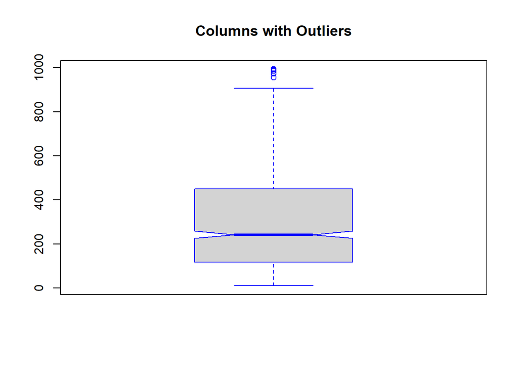

```r
#plotting to visualize the outliers
boxplot(pca_df_num$cogs,
        main="Columns with Outliers",names = c("cogs"),border = "Blue",notch = TRUE)
```

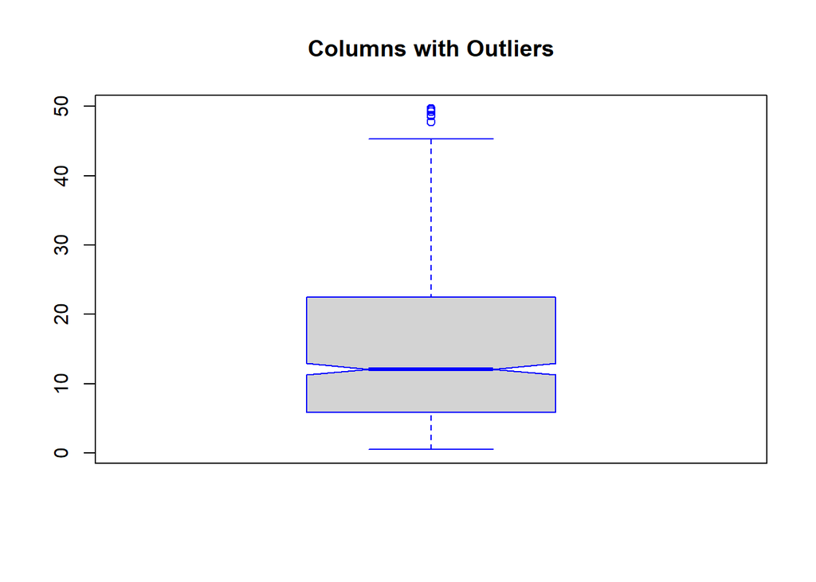

```r
#plotting to visualize the outliers
boxplot(pca_df_num$gross.income,
        main="Columns with Outliers",names = c("gross.income"),border = "Blue",notch = TRUE)
```

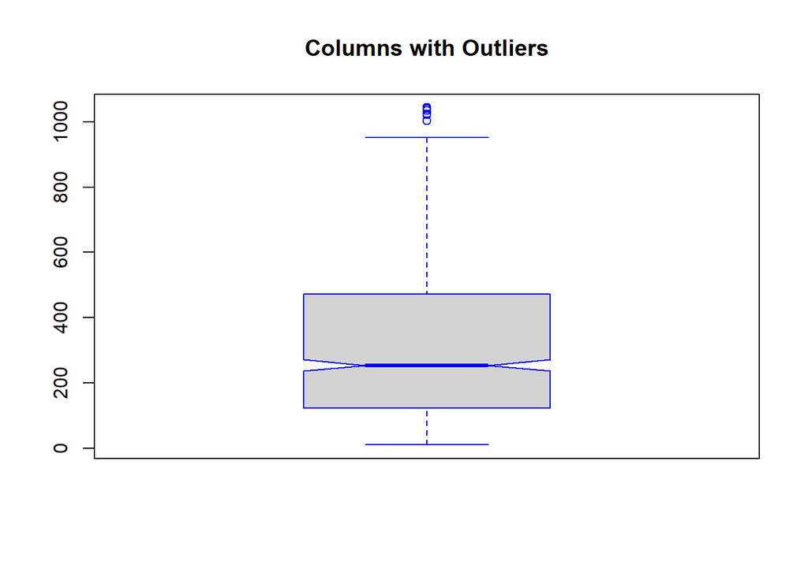

```r
#plotting to visualize the outliers
boxplot(pca_df_num$Total,
        main="Columns with Outliers",names = c("Total"),border = "Blue",notch = TRUE)
```

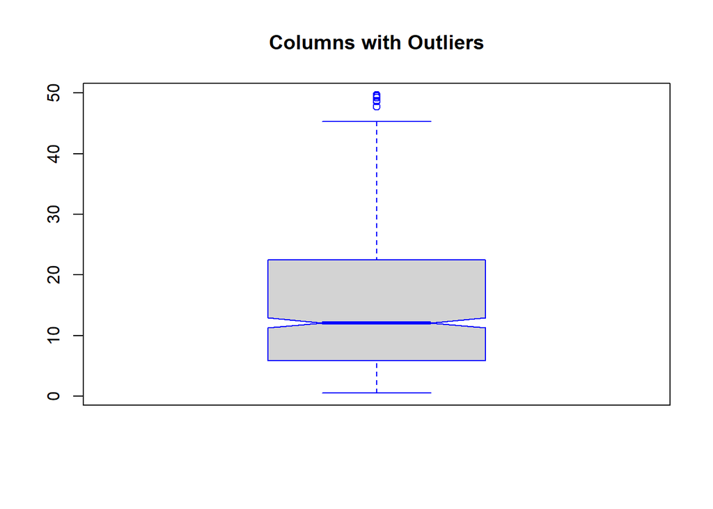

```r
#plotting to visualize the outliers
boxplot(pca_df_num$Tax,
        main="Columns with Outliers",names = c("Tax"),border = "Blue",notch = TRUE)
```

```r
#Removing Outliers

#quartiles <- quantile(pca_df_num, probs=c(.25, .75), na.rm = FALSE)
#IQR <- IQR(pca_df_num)
#Lower <- quartiles[1] - 1.5*IQR
#Upper <- quartiles[2] + 1.5*IQR
#data_no_outlier <- subset(pca_df_num > Lower & pca_df_num < Upper)
#dim(data_no_outlier)
```

# Feature Engineering

Splitting Date into Year, Month and Day and also time into Hours and Minutes

```r
#Spriting date into Year,Month and Day
pca_df<-separate(pca_df,Date, c("Month","Day","Year"))
```

```r
#Spritting Day into hours and minutes
pca_df<-separate(pca_df,Time, c("Hours","Minutes"))
 colnames(pca_df)
```

```
##  [1] "Invoice.ID"              "Branch"
##  [3] "Customer.type"           "Gender"
##  [5] "Product.line"            "Unit.price"
##  [7] "Quantity"                "Tax"
##  [9] "Month"                   "Day"
## [11] "Year"                    "Hours"
## [13] "Minutes"                 "Payment"
## [15] "cogs"                    "gross.margin.percentage"
## [17] "gross.income"            "Rating"
## [19] "Total"
```

-Date has been successfully separated into Year, Month and Day and also has been successfully separated into Hours and Minutes

# Univariate Analysis

## Calculating Descriptive statistics using describe()

describe() computes descriptive statistic for numerical data which helps to determine the distribution of numerical variables.

```r
describe(pca_df_num)
```

```
##                         vars    n   mean     sd median trimmed    mad   min
## Unit.price                 1 1000  55.67  26.49  55.23   55.62  33.37 10.08
## Quantity                   2 1000   5.51   2.92   5.00    5.51   2.97  1.00
## Tax                        3 1000  15.38  11.71  12.09   14.00  11.13  0.51
## cogs                       4 1000 307.59 234.18 241.76  279.91 222.65 10.17
## gross.margin.percentage    5 1000   4.76   0.00   4.76    4.76   0.00  4.76
## gross.income               6 1000  15.38  11.71  12.09   14.00  11.13  0.51
## Rating                     7 1000   6.97   1.72   7.00    6.97   2.22  4.00
## Total                      8 1000 322.97 245.89 253.85  293.91 233.78 10.68
##                             max   range skew kurtosis   se
## Unit.price                99.96   89.88 0.01    -1.22 0.84
## Quantity                  10.00    9.00 0.01    -1.22 0.09
## Tax                       49.65   49.14 0.89    -0.09 0.37
## cogs                     993.00  982.83 0.89    -0.09 7.41
## gross.margin.percentage    4.76    0.00  NaN      NaN 0.00
## gross.income              49.65   49.14 0.89    -0.09 0.37
## Rating                    10.00    6.00 0.01    -1.16 0.05
## Total                   1042.65 1031.97 0.89    -0.09 7.78
```

## Plotting histogram for numeric data

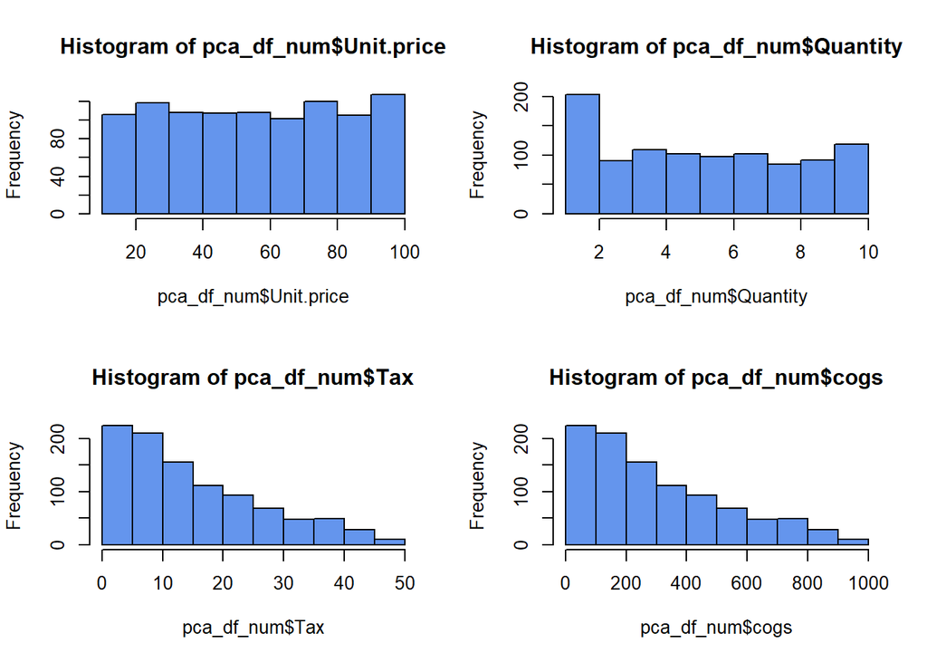

```r
par(mfrow = c(2,2))
hist(pca_df_num$Unit.price, col = "cornflowerblue")
hist(pca_df_num$Quantity,col = "cornflowerblue")
hist(pca_df_num$Tax,col = "cornflowerblue")
hist(pca_df_num$cogs,col = "cornflowerblue")
```

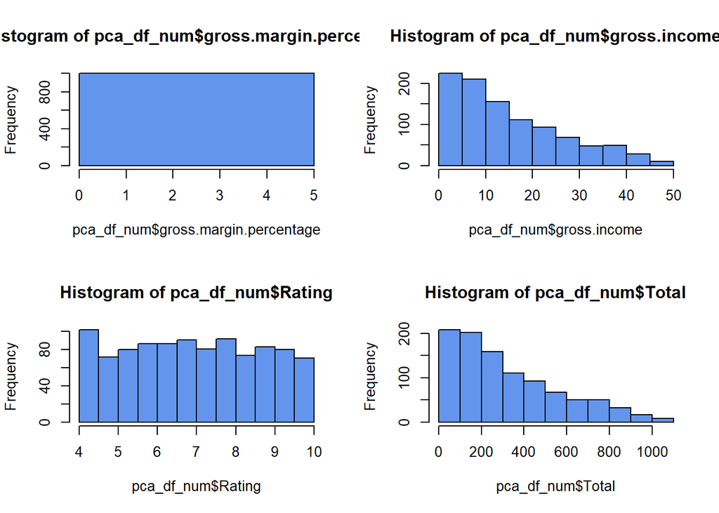

```r
hist(pca_df_num$gross.margin.percentage, col = "cornflowerblue")
hist(pca_df_num$gross.income,col = "cornflowerblue")
hist(pca_df_num$Rating,col = "cornflowerblue")
hist(pca_df_num$Total,col = "cornflowerblue")
```

Observations:

-Rating and unit price has almost equal distribution

## Plotting bar graphs for categorical variables

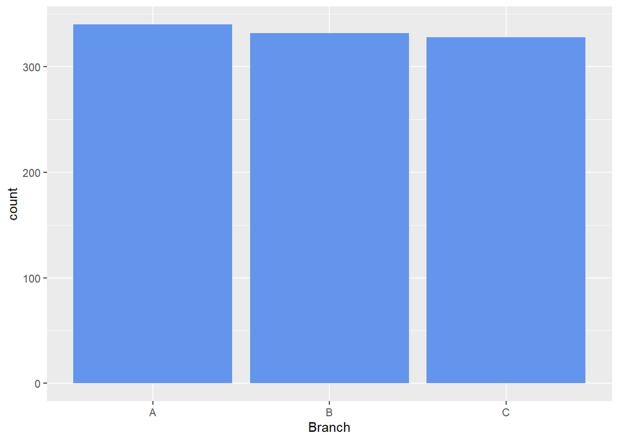

```r
#Branch
ggplot(pca_df, aes(Branch))+ geom_bar(fill ="cornflowerblue")
```

Observation:

-We have three branches, A,B and C of which they have equal distribution

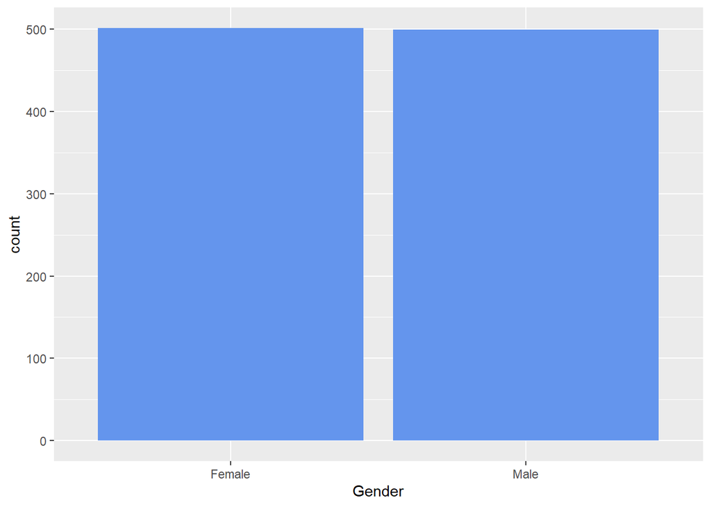

```r
#Gender
ggplot(pca_df, aes(Gender))+ geom_bar(fill ="cornflowerblue")
```

Observation:

- We have two types of gender, Female and male

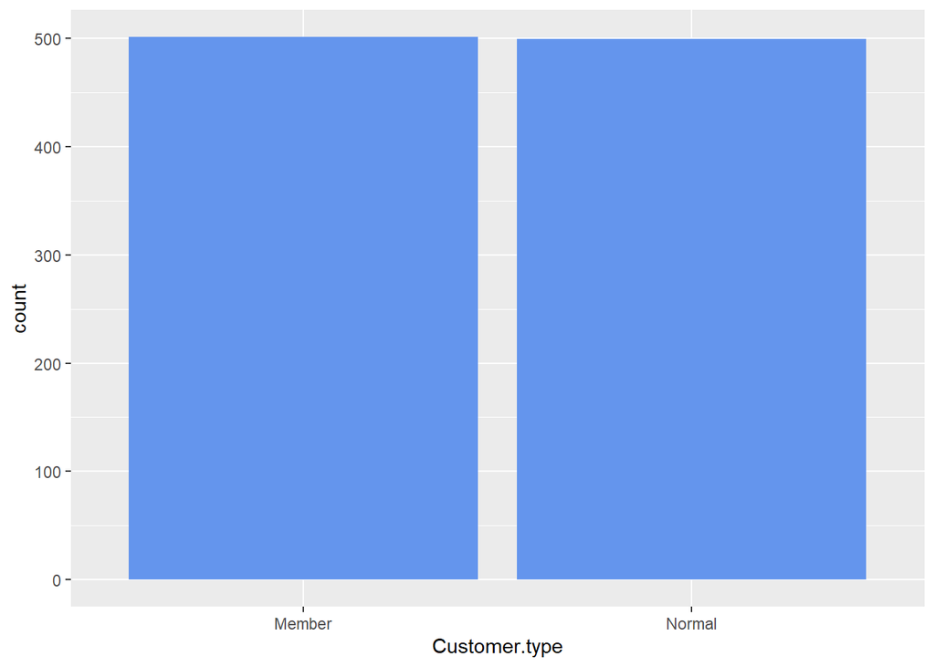

```r
#Customer.type
ggplot(pca_df, aes(Customer.type))+ geom_bar(fill ="cornflowerblue")
```

Observation:

-There are two types of customer types that is Member and Normal which are equally distribution.

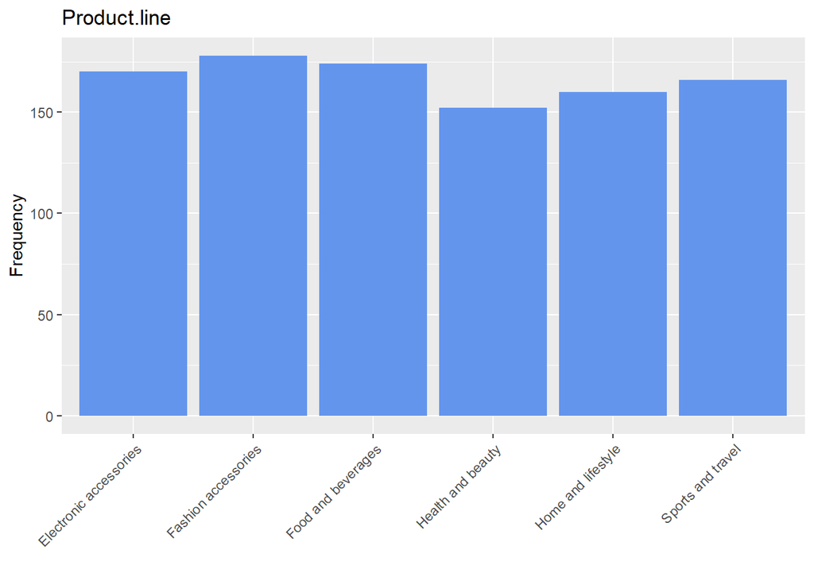

```r
ggplot(pca_df, aes(x = Product.line)) +
  geom_bar(fill ="cornflowerblue") +
  labs(x = "",
       y = "Frequency",
       title = "Product.line") +
  theme(axis.text.x = element_text(angle = 45,
                                   hjust = 1))
```

Observation:

-There are 6 types of product line which includes: Health and beauty, Electronic accessories, Home and lifestyle , Sports and travel,Food and beverages,Fashion accessories.

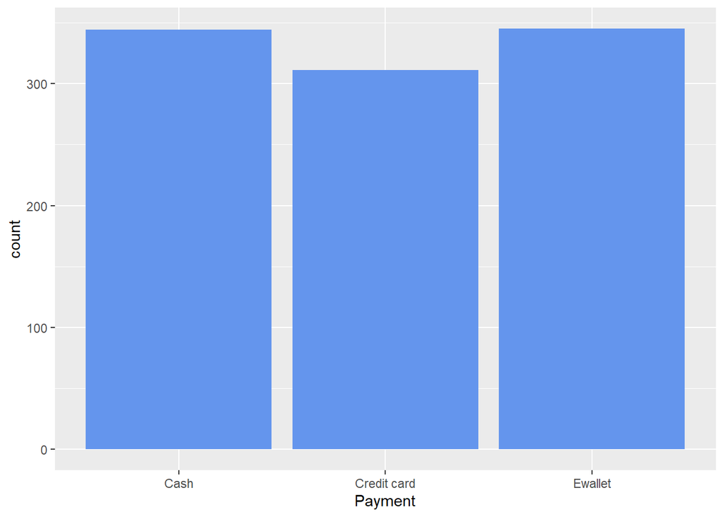

```r
#Payment
ggplot(pca_df, aes(Payment))+ geom_bar(fill ="cornflowerblue")
```

Observation:

- There are three modes of payment: Cash,Credit Card and Ewallet. Credit card is the least commolly used.

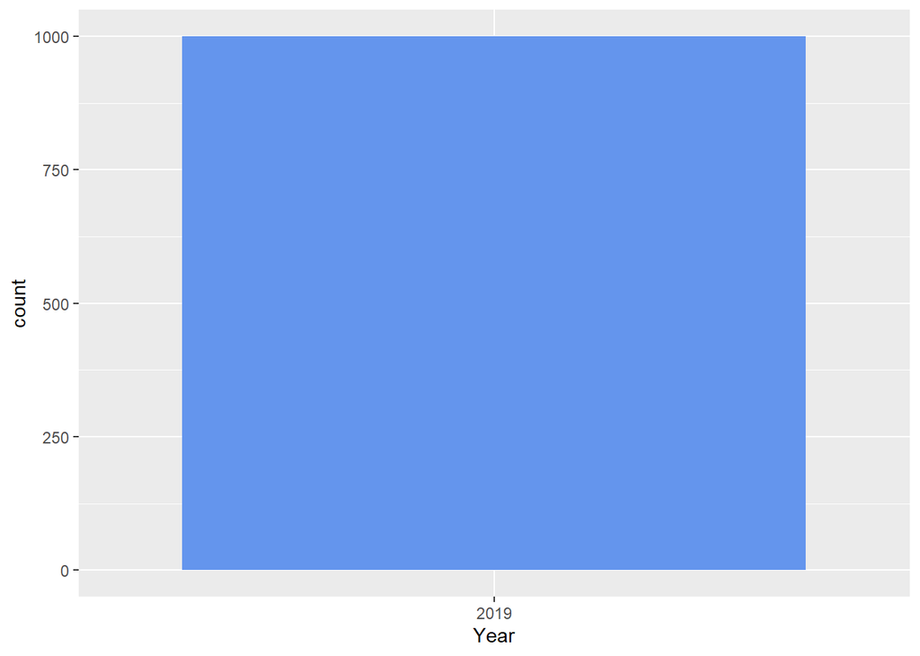

```r
#Year
ggplot(pca_df, aes(Year))+ geom_bar(fill ="cornflowerblue")
```

- Observation.

There is only one year, that is 2019.

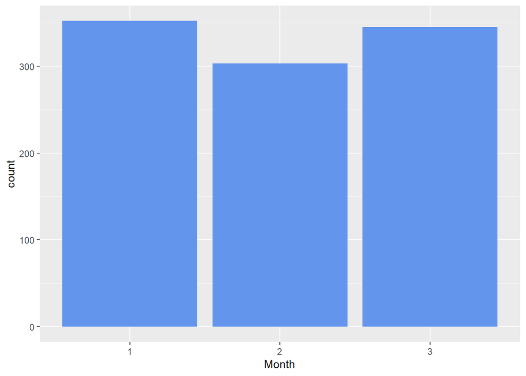

```r
#Month
ggplot(pca_df, aes(Month))+ geom_bar(fill ="cornflowerblue")
```

Observation:

- The study was conducted in a period of three months.

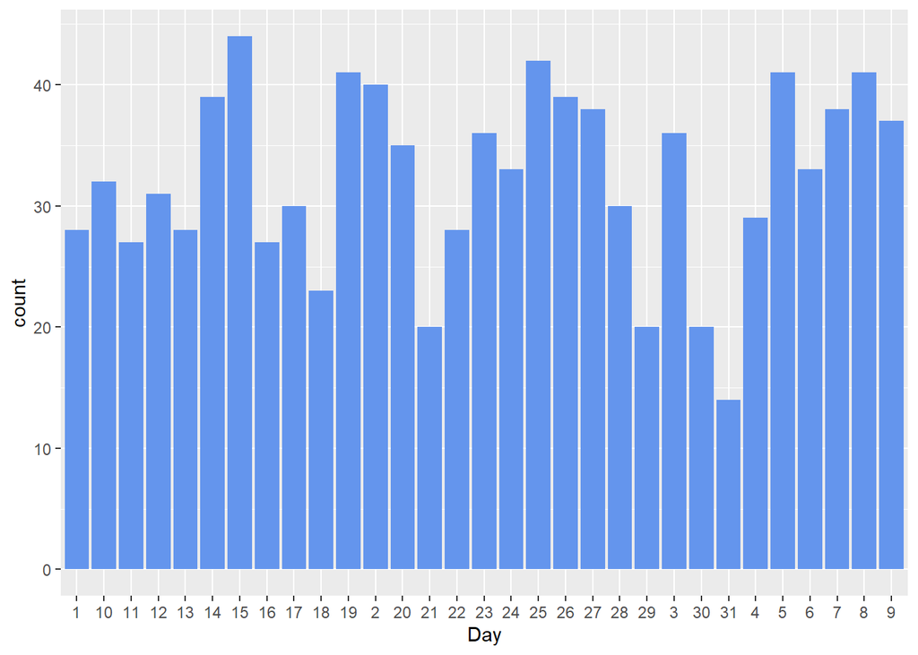

```r
#Day
ggplot(pca_df, aes(Day))+ geom_bar(fill ="cornflowerblue")
```

observation:

The study was conducted in all days of the month.

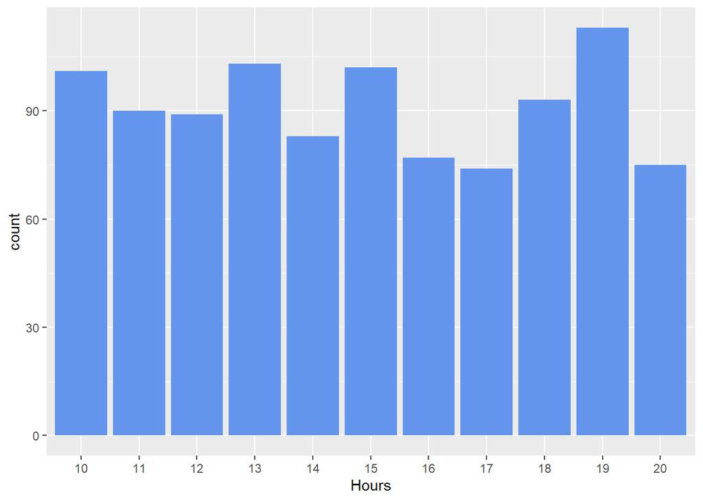

```r
#Hour
ggplot(pca_df, aes(Hours))+ geom_bar(fill ="cornflowerblue")
```

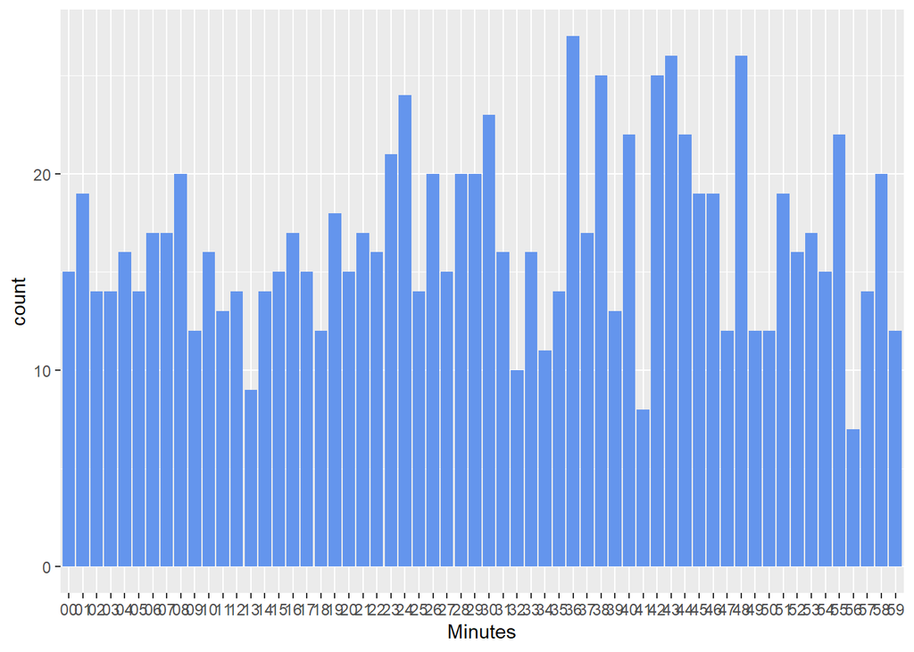

```r
#Minute
ggplot(pca_df, aes(Minutes))+ geom_bar(fill ="cornflowerblue")
```

# Bivariate Analysis

## Covariance

```r
var(pca_df_num)
```

```
##                           Unit.price     Quantity          Tax        cogs
## Unit.price               701.9653313   0.83477848  196.6683401  3933.36680
## Quantity                   0.8347785   8.54644645   24.1495704   482.99141
## Tax                      196.6683401  24.14957038  137.0965941  2741.93188
## cogs                    3933.3668019 482.99140761 2741.9318829 54838.63766
## gross.margin.percentage    0.0000000   0.00000000    0.0000000     0.00000
## gross.income             196.6683401  24.14957038  137.0965941  2741.93188
## Rating                    -0.3996675  -0.07945646   -0.7333003   -14.66601
## Total                   4130.0351420 507.14097799 2879.0284770 57580.56954
##                         gross.margin.percentage gross.income       Rating
## Unit.price                                    0  196.6683401  -0.39966752
## Quantity                                      0   24.1495704  -0.07945646
## Tax                                           0  137.0965941  -0.73330028
## cogs                                          0 2741.9318829 -14.66600553
## gross.margin.percentage                       0    0.0000000   0.00000000
## gross.income                                  0  137.0965941  -0.73330028
## Rating                                        0   -0.7333003   2.95351823
## Total                                         0 2879.0284770 -15.39930581
##                               Total
## Unit.price               4130.03514
## Quantity                  507.14098
## Tax                      2879.02848
## cogs                    57580.56954
## gross.margin.percentage     0.00000
## gross.income             2879.02848
## Rating                    -15.39931
## Total                   60459.59802
```

Observation:

gross.margin.percentage has no variance hence it will be dropped.

```r
#Dropping Columns
pca_df<-select(pca_df,-c(gross.margin.percentage,Year,Invoice.ID))
```

## Correlation

```r
#corr<-cor(pca_df_num)
```

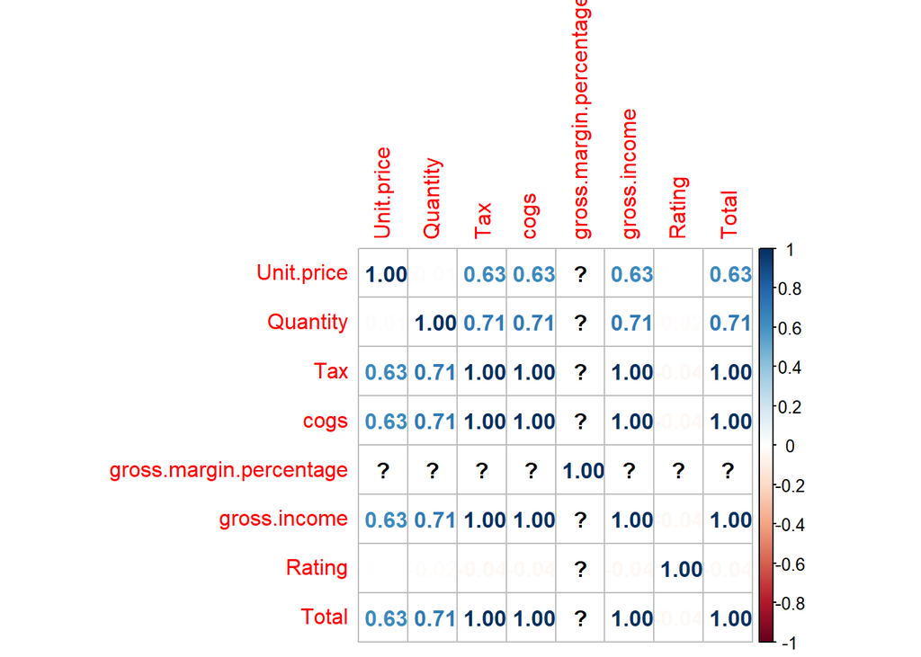

```r
library(corrplot)
corr<-corrplot(corr=cor(pca_df_num), method = "number")
```

## Plotting Grouped Bar chart for categorical vs Categorical

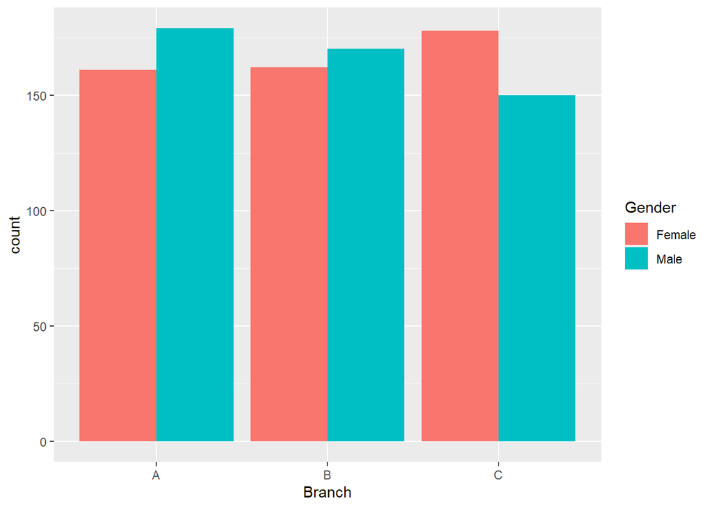

```r
library(ggplot2)
#Grouped Bar Chart
ggplot(pca_df, aes(x=Branch,fill=Gender))+ geom_bar(position = "dodge")
```

Observations:

- Branch A and B has more male compared to female
- Branch C has more female than male

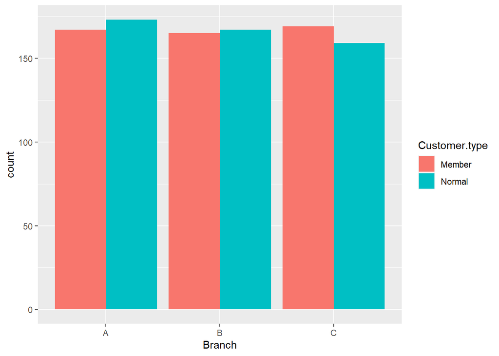

```r
#Grouped Bar Chart
ggplot(pca_df, aes(Branch,fill=Customer.type))+ geom_bar(position = "dodge")
```

Observation:

- The normal customers are more compared to member in Branch A
- In Branch B both Normal and Member customers are almost equal.
- In Branch C Member customers are more compared to Normal customers.

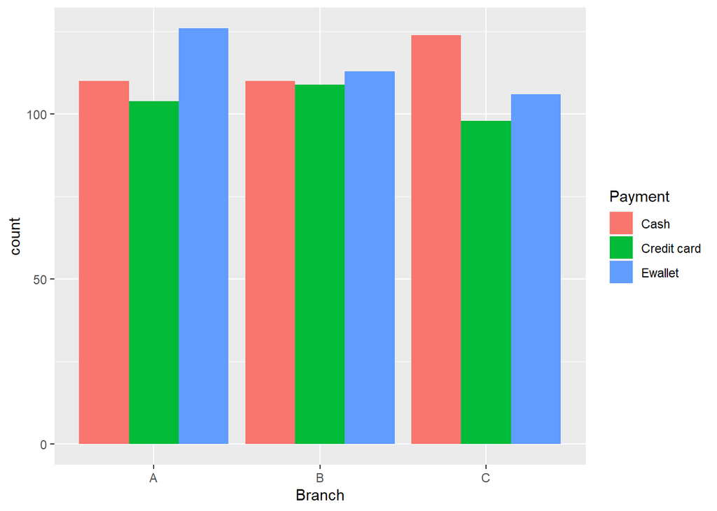

```r
#Grouped Bar Chart
ggplot(pca_df, aes(Branch,fill=Payment))+ geom_bar(position = "dodge")
```

Observations:

-In Branch B , all the forms of payment were almost balanced

- In Branch C, The most form of payment that was used was Cash and the least was Credit card.

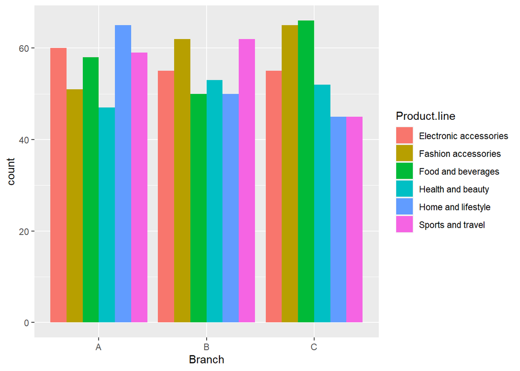

```r
#Grouped Bar Chart
ggplot(pca_df, aes(Branch,fill=Product.line))+ geom_bar(position = "dodge")
```

Observations:

- The most common product line that was found in Branch A was Home and Lifestyle,in B was Sport and Travel and in C was Food and beverages.

-The least in A was Health and beauty, in B was Home and lifestyle and in C was Sport and travel.

## Scatter Plots

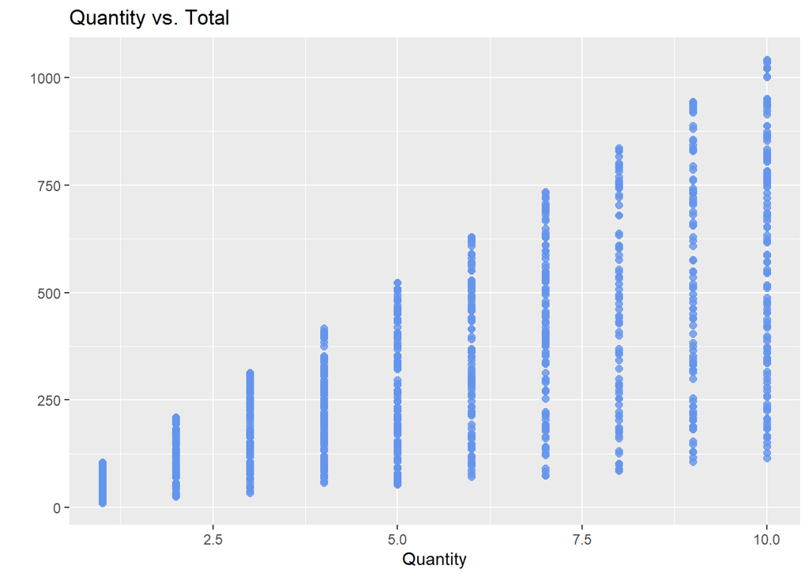

```r
ggplot(pca_df,
       aes(x = Quantity,
           y = Total)) +
  geom_point(color="cornflowerblue",
             size = 2,
             alpha=.8) +

  labs(x = "Quantity",
       y = "",
       title = "Quantity vs. Total",)
```

# Encoding

#### Converting Character to numeric

```r
#converting Month, Day, Hour and Minutes  to numeric
pca_df$Month<- as.numeric(pca_df$Month)
pca_df$Day<- as.numeric(pca_df$Day)
pca_df$Hours<- as.numeric(pca_df$Hours)
pca_df$Minutes<- as.numeric(pca_df$Minutes)
```

## Label Encoding categorical variables

```r
glimpse(pca_df)
```

```
## Rows: 1,000
## Columns: 16
## $ Branch        <fct> A, C, A, A, A, C, A, C, A, B, B, B, A, A, A, B, A, A, A,…
## $ Customer.type <fct> Member, Normal, Normal, Member, Normal, Normal, Member, …
## $ Gender        <fct> Female, Female, Male, Male, Male, Male, Female, Female, …
## $ Product.line  <fct> Health and beauty, Electronic accessories, Home and life…
## $ Unit.price    <dbl> 74.69, 15.28, 46.33, 58.22, 86.31, 85.39, 68.84, 73.56, …
## $ Quantity      <int> 7, 5, 7, 8, 7, 7, 6, 10, 2, 3, 4, 4, 5, 10, 10, 6, 7, 6,…
## $ Tax           <dbl> 26.1415, 3.8200, 16.2155, 23.2880, 30.2085, 29.8865, 20.…
## $ Month         <dbl> 1, 3, 3, 1, 2, 3, 2, 2, 1, 2, 2, 3, 2, 2, 3, 1, 3, 1, 1,…
## $ Day           <dbl> 5, 8, 3, 27, 8, 25, 25, 24, 10, 20, 6, 9, 12, 7, 29, 15,…
## $ Hours         <dbl> 13, 10, 13, 20, 10, 18, 14, 11, 17, 13, 18, 17, 10, 16, …
## $ Minutes       <dbl> 8, 29, 23, 33, 37, 30, 36, 38, 15, 27, 7, 3, 25, 48, 21,…
## $ Payment       <fct> Ewallet, Cash, Credit card, Ewallet, Ewallet, Ewallet, E…
## $ cogs          <dbl> 522.83, 76.40, 324.31, 465.76, 604.17, 597.73, 413.04, 7…
## $ gross.income  <dbl> 26.1415, 3.8200, 16.2155, 23.2880, 30.2085, 29.8865, 20.…
## $ Rating        <dbl> 9.1, 9.6, 7.4, 8.4, 5.3, 4.1, 5.8, 8.0, 7.2, 5.9, 4.5, 6…
## $ Total         <dbl> 548.9715, 80.2200, 340.5255, 489.0480, 634.3785, 627.616…
```

```r
#Defining one-hot encoding function
dummy<- dummyVars("~ .", data = pca_df)
#performing one-hot encoding on data frame
pca_df<-data.frame(predict(dummy,newdata=pca_df))

#Viewing the dataframe
glimpse(pca_df)
```

```
## Rows: 1,000
## Columns: 27
## $ Branch.A                            <dbl> 1, 0, 1, 1, 1, 0, 1, 0, 1, 0, 0, 0…
## $ Branch.B                            <dbl> 0, 0, 0, 0, 0, 0, 0, 0, 0, 1, 1, 1…
## $ Branch.C                            <dbl> 0, 1, 0, 0, 0, 1, 0, 1, 0, 0, 0, 0…
## $ Customer.type.Member                <dbl> 1, 0, 0, 1, 0, 0, 1, 0, 1, 1, 1, 1…
## $ Customer.type.Normal                <dbl> 0, 1, 1, 0, 1, 1, 0, 1, 0, 0, 0, 0…
## $ Gender.Female                       <dbl> 1, 1, 0, 0, 0, 0, 1, 1, 1, 1, 1, 0…
## $ Gender.Male                         <dbl> 0, 0, 1, 1, 1, 1, 0, 0, 0, 0, 0, 1…
## $ Product.line.Electronic.accessories <dbl> 0, 1, 0, 0, 0, 1, 1, 0, 0, 0, 0, 1…
## $ Product.line.Fashion.accessories    <dbl> 0, 0, 0, 0, 0, 0, 0, 0, 0, 0, 1, 0…
## $ Product.line.Food.and.beverages     <dbl> 0, 0, 0, 0, 0, 0, 0, 0, 0, 1, 0, 0…
## $ Product.line.Health.and.beauty      <dbl> 1, 0, 0, 1, 0, 0, 0, 0, 1, 0, 0, 0…
## $ Product.line.Home.and.lifestyle     <dbl> 0, 0, 1, 0, 0, 0, 0, 1, 0, 0, 0, 0…
## $ Product.line.Sports.and.travel      <dbl> 0, 0, 0, 0, 1, 0, 0, 0, 0, 0, 0, 0…
## $ Unit.price                          <dbl> 74.69, 15.28, 46.33, 58.22, 86.31,…
## $ Quantity                            <dbl> 7, 5, 7, 8, 7, 7, 6, 10, 2, 3, 4, …
## $ Tax                                 <dbl> 26.1415, 3.8200, 16.2155, 23.2880,…
## $ Month                               <dbl> 1, 3, 3, 1, 2, 3, 2, 2, 1, 2, 2, 3…
## $ Day                                 <dbl> 5, 8, 3, 27, 8, 25, 25, 24, 10, 20…
## $ Hours                               <dbl> 13, 10, 13, 20, 10, 18, 14, 11, 17…
## $ Minutes                             <dbl> 8, 29, 23, 33, 37, 30, 36, 38, 15,…
## $ Payment.Cash                        <dbl> 0, 1, 0, 0, 0, 0, 0, 0, 0, 0, 0, 1…
## $ Payment.Credit.card                 <dbl> 0, 0, 1, 0, 0, 0, 0, 0, 1, 1, 0, 0…
## $ Payment.Ewallet                     <dbl> 1, 0, 0, 1, 1, 1, 1, 1, 0, 0, 1, 0…
## $ cogs                                <dbl> 522.83, 76.40, 324.31, 465.76, 604…
## $ gross.income                        <dbl> 26.1415, 3.8200, 16.2155, 23.2880,…
## $ Rating                              <dbl> 9.1, 9.6, 7.4, 8.4, 5.3, 4.1, 5.8,…
## $ Total                               <dbl> 548.9715, 80.2200, 340.5255, 489.0…
```

# Principal Component Analysis

```r
library(factoextra)
pca_df.pca <- prcomp(pca_df, scale. = TRUE)
#summary(pca_df.pca)
```

```r
#Getting the Eingenvalues
pca_eig<-get_eigenvalue(pca_df.pca)
pca_eig
```

```
##          eigenvalue variance.percent cumulative.variance.percent
## Dim.1  4.940061e+00     1.829652e+01                    18.29652
## Dim.2  2.151430e+00     7.968260e+00                    26.26478
## Dim.3  1.959596e+00     7.257763e+00                    33.52254
## Dim.4  1.599003e+00     5.922232e+00                    39.44478
## Dim.5  1.556132e+00     5.763451e+00                    45.20823
## Dim.6  1.492683e+00     5.528455e+00                    50.73668
## Dim.7  1.471607e+00     5.450395e+00                    56.18708
## Dim.8  1.252028e+00     4.637141e+00                    60.82422
## Dim.9  1.231182e+00     4.559934e+00                    65.38415
## Dim.10 1.195900e+00     4.429261e+00                    69.81341
## Dim.11 1.194098e+00     4.422585e+00                    74.23600
## Dim.12 1.148466e+00     4.253576e+00                    78.48957
## Dim.13 1.113823e+00     4.125269e+00                    82.61484
## Dim.14 1.025554e+00     3.798347e+00                    86.41319
## Dim.15 9.525527e-01     3.527973e+00                    89.94116
## Dim.16 9.191631e-01     3.404308e+00                    93.34547
## Dim.17 8.904927e-01     3.298121e+00                    96.64359
## Dim.18 8.169815e-01     3.025857e+00                    99.66945
## Dim.19 8.924915e-02     3.305524e-01                   100.00000
## Dim.20 3.203557e-29     1.186503e-28                   100.00000
## Dim.21 2.306596e-29     8.542950e-29                   100.00000
## Dim.22 7.947896e-30     2.943665e-29                   100.00000
## Dim.23 6.285212e-30     2.327856e-29                   100.00000
## Dim.24 1.076578e-30     3.987325e-30                   100.00000
## Dim.25 4.762776e-32     1.763991e-31                   100.00000
## Dim.26 4.475785e-32     1.657698e-31                   100.00000
## Dim.27 2.903530e-32     1.075381e-31                   100.00000
```

## Plotting PCA

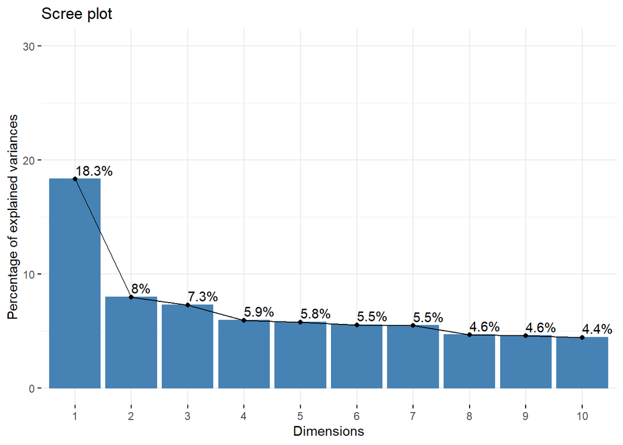

```r
fviz_eig(pca_df.pca,addlabels = T, ylim=c(0,30))
```

- Dim.1 accounts for 18.3% of the data.

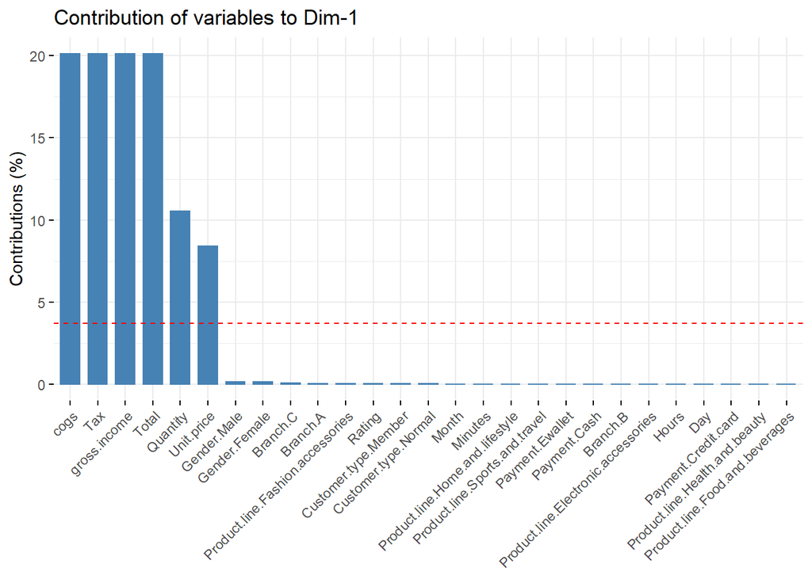

```r
#Plotting the contribution of attributes in various principal components
par(mfrow = c(2,2))
fviz_contrib(pca_df.pca,choice = "var",axes = 1)
```

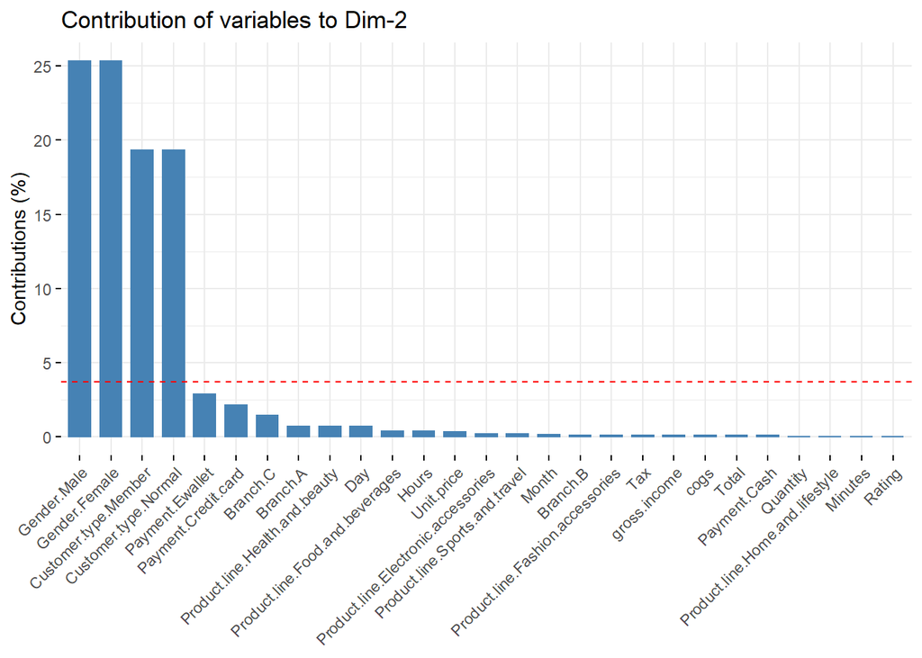

```r
fviz_contrib(pca_df.pca,choice = "var",axes = 2)
```

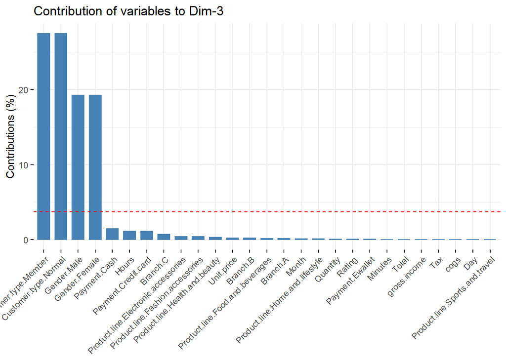

```r
fviz_contrib(pca_df.pca,choice = "var",axes = 3)
```

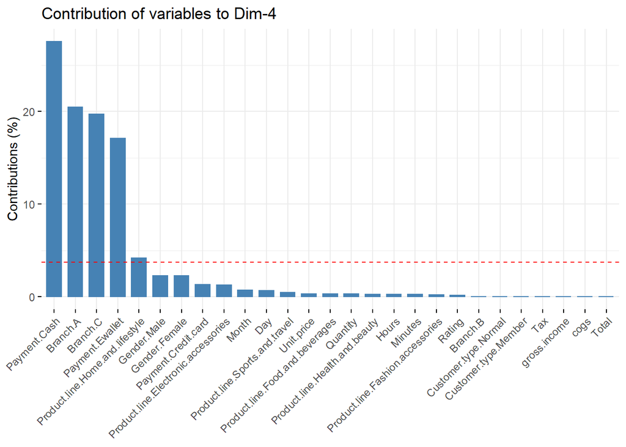

```r
fviz_contrib(pca_df.pca,choice = "var",axes = 4)
```

- In PC1, the major contributors are cogs, Tax, gross.income and total.
- In PC2, the major contributors are male, female customer type Normal and Member
- In PC3, the major contributors are customer type member and Normal and gender male and female

```r
#pca_df.pca
```

_The principal components are 27 hence they occupy a lot of space when they are all printed